# Chapter 8 - Themes

Davor  
November 24, 2014

### Themes in Ggplot

- Control appearance of non-data elements
- E.g., title and axis label fonts, grid lines, background colour

### Applying themes

- Built-in themes (call with `theme_`*name*`()`):
  - grey
  - bw
  - linedraw
  - light
  - minimal
  - classic
- Set as default: `theme_set(theme_light())`
- Apply locally: `qplot() + theme_classic()`

### Adjusting theme elements

- `theme(`*element*`=` *element_function*`)`

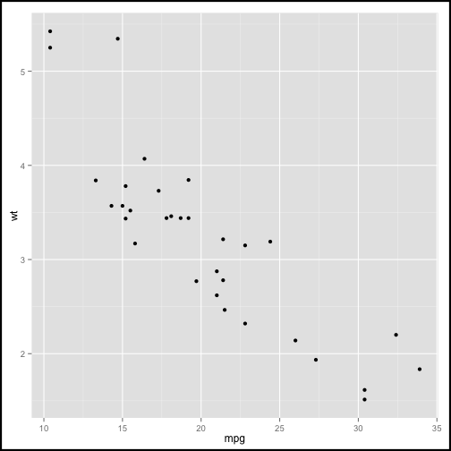

```r
qplot(mpg, wt, data = mtcars) +
  theme(plot.background = element_rect(size=2, colour = 'black'))
```

### Theme elements

Hierarchy of names separated by dots:

- plot:
  - title, background
- axis:
  - text (x and y), title (x and y)
  - line, ticks
- panel:
  - grid.major, grid.minor
  - background, border
- legend:
  - text, title
  - background, key
- strip:
  - text (x and y)
  - background

### Element functions

**Names changed from the book!!**

- `element_text`: text, title
- `element_line`: line, ticks, grid
- `element_rect`: background, border, key

### Exercises

- We'll use the PlantGrowth dataset:

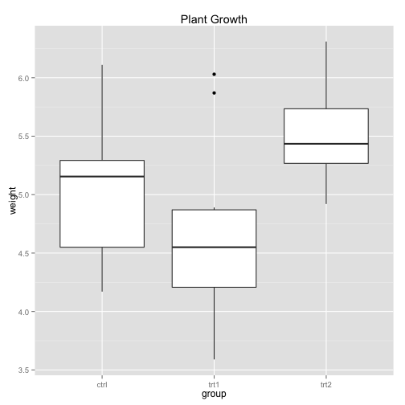

```r
bp <- ggplot(PlantGrowth, aes(x=group, y=weight)) + geom_boxplot() + ggtitle('Plant Growth')
```

### Exercise: Change label appearance

- Hide the X-axis label
- Make the title twice as big as base size
- Rotate X-axis tick marks

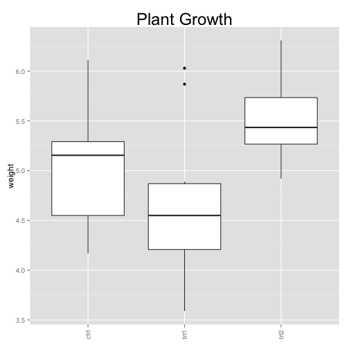

### Exercise: Manipulate grid lines

- Make horizontal major grid lines dotted
- Hide horizontal minor grid lines
- Hide all vertical lines

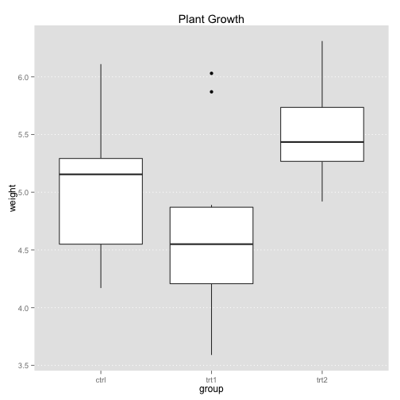

### Exercise: Legend

```r
bpl <- bp + aes(fill=group)
```

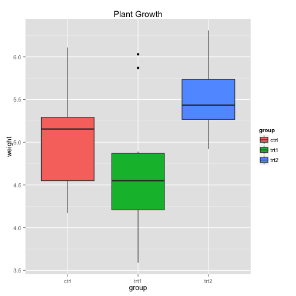

### Exercise: Hide legend

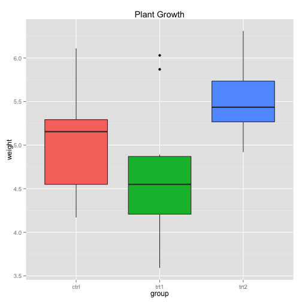

```r
bpl + theme(legend.position = "none")
```

### Exercise: Legend placement

- Move legend to the bottom-right corner

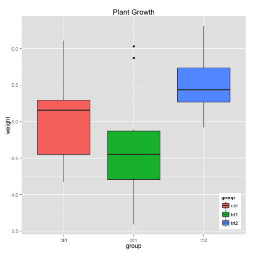

### Exercise: Legend appearance

- Put a gray rectangle behind the legend
- Make legend title italic

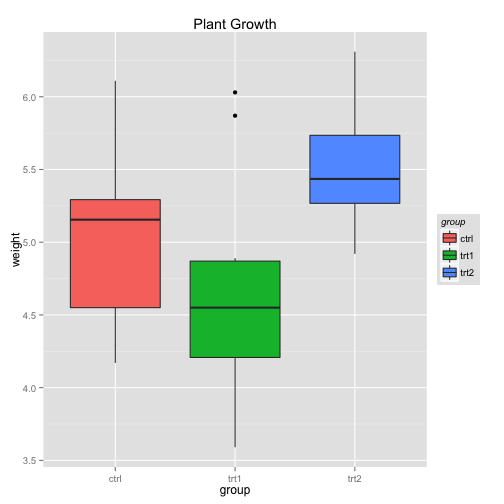

### Exercise: Facetting

- Density plot of 'weight' facetted by 'group'

  ```r
  qplot(weight, data = PlantGrowth, geom = 'density') +
  facet_wrap(~group)
  ```

- Facet labels are bold on pink background

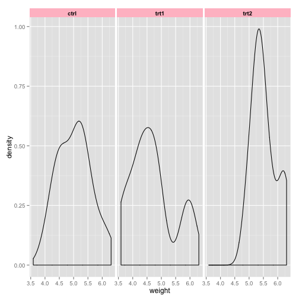

### Customizing scale defaults

- **Changed from the book!!**
- `set_default_scale` has been removed
- To change the default scale for an aesthetic, create a function called `scale_`*aesthetic*`_`*type* that returns the desired scale
  - scale type is usually “continuous”“ or "discrete”
  - e.g., `scale_fill_continuous` defines the default *continuous* scale for the *fill* aesthetic
- To restore the Ggplot2's default scale, remove the object you just created (e.g., `rm(scale_fill_continuous)`)

### Example: Customizing scale defaults

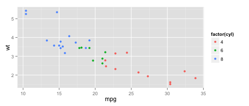

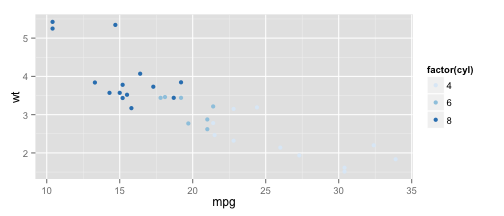

```r
p <- qplot(mpg, wt, data = mtcars, colour = factor(cyl))
p
## Use Brewer as the default discrete colour scale
scale_colour_discrete <- scale_colour_brewer
p
## Restore defaults
rm(scale_colour_discrete)
p
```

### Ggthemes

- Package of additional Ggplot themes
- Available on CRAN

  ```r
  install.packages('ggthemes', dependencies = TRUE)
  ```

- Development version on Github comes with more themes:

  ```r
  install_github('jrnold/ggthemes')
  library(ggthemes)
  ```

### Tufte

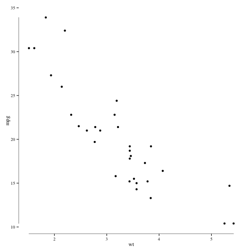

```r
qplot(wt, mpg, data = mtcars) +
  geom_rangeframe() +
  theme_tufte()
```

### Economist

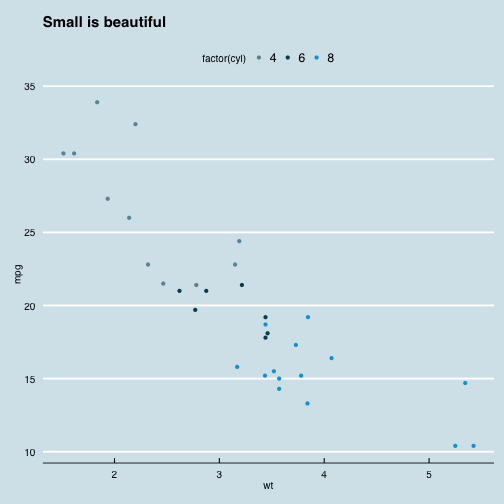

```r
qplot(wt, mpg, data = mtcars, colour = factor(cyl)) +
  theme_economist() +
  scale_colour_economist() +
  ggtitle('Small is beautiful')
```

### Wall Street Journal

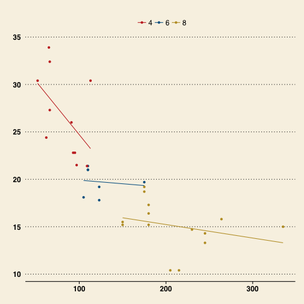

```r
qplot(hp, mpg, data= mtcars, color = factor(cyl)) +
 geom_smooth(method = "lm", se = FALSE) +
 scale_colour_wsj("colors6", "") +
 theme_wsj()
```

### Excel

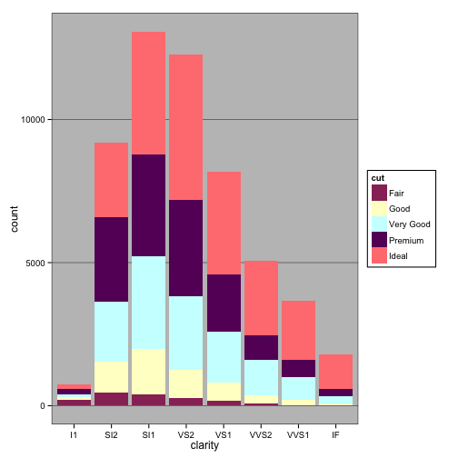

```r
ggplot(diamonds, aes(clarity, fill=cut)) +
 geom_bar() +
 scale_fill_excel() +
 theme_excel()
```

### XKCD

- http://xkcd.r-forge.r-project.org

[figure not shown]

- I couldn't get it to find the 'xkcd' font I installed (on OS X), YMWV

### Ggplot2 Theme Builder

- Shiny app for a point-and-click way to build Ggplot2 themes
- https://bchartoff.shinyapps.io/ggShinyApp/